# Practical Machine Learning Project

## Data Partitioning

Library ‘caret’ is loaded. The provided data sets are imported from the working directory. The training data set is partitioned into 70% for training and the remaining 30% for testing.

```r
library(caret)
set.seed(975)
data = read.csv("pml-training.csv", header = TRUE, sep = ",")
prediction_data = read.csv("pml-testing.csv", header = TRUE, sep = ",")
inTrain = createDataPartition(data$classe, p=.7)[[1]]
training = data[inTrain,]
testing = data[-inTrain,]
```

## Irrelevant Data

The first 7 columns are for recording purpose which are irrelevant to the prediction and therefore removed from the data sets.

```r
training_ss = training[,-(1:7)]
testing_ss = testing[,-(1:7)]
prediction_ss = prediction_data[,-(1:7)]
```

## Zero Covariates

The training data is examined for zero covariates.

```r
nearZeroVar(training_ss,saveMetrics=T)
```

```
##                            freqRatio percentUnique zeroVar   nzv
## roll_belt                   1.141956    8.10220572   FALSE FALSE
## pitch_belt                  1.029412   12.17150761   FALSE FALSE
## yaw_belt                    1.037736   13.04506078   FALSE FALSE
## total_accel_belt            1.050747    0.19654946   FALSE FALSE
## kurtosis_roll_belt       1922.428571    2.00189270   FALSE  TRUE
## kurtosis_picth_belt       747.611111    1.73982675   FALSE  TRUE
## kurtosis_yaw_belt          48.060714    0.01455922   FALSE  TRUE
## skewness_roll_belt       2242.833333    2.00917231   FALSE  TRUE
## skewness_roll_belt.1      747.611111    1.80534323   FALSE  TRUE
## skewness_yaw_belt          48.060714    0.01455922   FALSE  TRUE
## max_roll_belt               1.250000    1.18657640   FALSE FALSE
## max_picth_belt              1.634146    0.15287181   FALSE FALSE
## max_yaw_belt              585.086957    0.40765815   FALSE  TRUE
## min_roll_belt               1.250000    1.10650069   FALSE FALSE
## min_pitch_belt              1.863636    0.10191454   FALSE FALSE
## min_yaw_belt              585.086957    0.40765815   FALSE  TRUE
## amplitude_roll_belt         1.263158    0.88083279   FALSE FALSE
## amplitude_pitch_belt        2.535714    0.09463493   FALSE FALSE
## amplitude_yaw_belt         49.840741    0.02911844   FALSE  TRUE
## var_total_accel_belt        1.423729    0.36398049   FALSE FALSE
## avg_roll_belt               1.272727    1.08466186   FALSE FALSE
## stddev_roll_belt            1.205882    0.37126010   FALSE FALSE
## var_roll_belt               1.454545    0.49501347   FALSE FALSE
## avg_pitch_belt              1.000000    1.22297445   FALSE FALSE
## stddev_pitch_belt           1.043478    0.23294751   FALSE FALSE
## var_pitch_belt              1.161765    0.32758244   FALSE FALSE
## avg_yaw_belt                1.000000    1.33944821   FALSE FALSE
## stddev_yaw_belt             1.588235    0.32030283   FALSE FALSE
## var_yaw_belt                1.517241    0.78619786   FALSE FALSE
## gyros_belt_x                1.143165    0.92451045   FALSE FALSE
## gyros_belt_y                1.135535    0.46589503   FALSE FALSE
## gyros_belt_z                1.052050    1.19385601   FALSE FALSE
## accel_belt_x                1.055453    1.16473757   FALSE FALSE
## accel_belt_y                1.087477    1.00458615   FALSE FALSE
## accel_belt_z                1.076423    2.10380724   FALSE FALSE
## magnet_belt_x               1.035294    2.22756060   FALSE FALSE
## magnet_belt_y               1.051282    2.05284997   FALSE FALSE
## magnet_belt_z               1.030120    3.17390988   FALSE FALSE
## roll_arm                   47.215686   17.42010628   FALSE FALSE
```

[output cut: 99 more lines]

```
## stddev_pitch_forearm       26.000000    1.65975104   FALSE  TRUE
## var_pitch_forearm          52.000000    1.66703065   FALSE  TRUE
## avg_yaw_forearm            52.000000    1.66703065   FALSE  TRUE
## stddev_yaw_forearm         54.000000    1.65247143   FALSE  TRUE
## var_yaw_forearm            54.000000    1.65247143   FALSE  TRUE
## gyros_forearm_x             1.033943    2.03101114   FALSE FALSE
## gyros_forearm_y             1.067164    5.24859868   FALSE FALSE
## gyros_forearm_z             1.103152    2.06012958   FALSE FALSE
## accel_forearm_x             1.171875    5.67081604   FALSE FALSE
## accel_forearm_y             1.043478    7.12673801   FALSE FALSE
## accel_forearm_z             1.081081    4.04746306   FALSE FALSE
## magnet_forearm_x            1.129630   10.61367111   FALSE FALSE
## magnet_forearm_y            1.147541   13.20521220   FALSE FALSE
## magnet_forearm_z            1.023810   11.64009609   FALSE FALSE
## classe                      1.469526    0.03639805   FALSE FALSE
```

As there are no zero covariates, no variable is removed from the training data set.

## Missing Data

The variables that have more than 90% empty string or ‘NA’ values are removed from the training data set, as the available data points of these variables are insufficient to be used for imputting. A function “data_availability” is defined to compute the proportion of available data points for each variable.

```r
data_availability = function(x) {
  countNA = sum(is.na(x)|(x==""))
  return((length(x)-countNA)/length(x))
}
training_ss2 = subset(training_ss,select=apply(training_ss,2,data_availability)>.9)
testing_ss2 = subset(testing_ss,select=apply(testing_ss,2,data_availability)>.9)
prediction_ss2 = subset(prediction_ss,select=apply(prediction_ss,2,data_availability)>.9)
```

## Variables Correlation

The correlations among the remaining 52 variables are examined, to explore the possibility of data compression.

```r
M = abs(cor(training_ss2[,-53]))
diag(M) = 0
which(M > 0.8,arr.ind=T)
```

```
##                  row col
## yaw_belt           3   1
## total_accel_belt   4   1
## accel_belt_y       9   1
## accel_belt_z      10   1
## accel_belt_x       8   2
## magnet_belt_x     11   2
## roll_belt          1   3
## roll_belt          1   4
## accel_belt_y       9   4
## accel_belt_z      10   4
## pitch_belt         2   8
## magnet_belt_x     11   8
## roll_belt          1   9
## total_accel_belt   4   9
## accel_belt_z      10   9
## roll_belt          1  10
## total_accel_belt   4  10
## accel_belt_y       9  10
## pitch_belt         2  11
## accel_belt_x       8  11
## gyros_arm_y       19  18
## gyros_arm_x       18  19
## magnet_arm_x      24  21
## accel_arm_x       21  24
## magnet_arm_z      26  25
## magnet_arm_y      25  26
## accel_dumbbell_x  34  28
## accel_dumbbell_z  36  29
## gyros_dumbbell_z  33  31
## gyros_forearm_z   46  31
## gyros_dumbbell_x  31  33
## gyros_forearm_z   46  33
## pitch_dumbbell    28  34
## yaw_dumbbell      29  36
## gyros_forearm_z   46  45
## gyros_dumbbell_x  31  46
## gyros_dumbbell_z  33  46
## gyros_forearm_y   45  46
```

High correlation (correlation > 0.8) is observed among several pairs of variables, which shows that the variables can be reduced.

## Principal Component Analysis

```r
preProc = preProcess(training_ss2[,-53], method = "pca", thresh = 0.99)
trainPC = predict(preProc,training_ss2[,-53])
testPC = predict(preProc,testing_ss2[,-53])
predictionPC = predict(preProc,prediction_ss2[,-53])
```

## Random Forest Algorithm with Cross-Validation

Random Forest algorithm is used to train the principal components obtained above, because it has high accuracy and runs efficiently on large data sets. 3-fold cross-validation is used to estimate the overall model accuracy, averaged over the iterations.

```r
trCtrl = trainControl(method = "cv", number = 3)
modelFit = train(training_ss2$classe~.,method="rf",data=trainPC,trControl=trCtrl,importance=T,ntree=100)
modelFit$finalModel
```

```
##
## Call:
##  randomForest(x = x, y = y, ntree = 100, mtry = param$mtry, importance = ..1)
##                Type of random forest: classification
##                      Number of trees: 100
## No. of variables tried at each split: 2
##
##         OOB estimate of  error rate: 2.77%
## Confusion matrix:
##      A    B    C    D    E class.error
## A 3877   16    6    3    4 0.007424475
## B   66 2553   30    4    5 0.039503386
## C    3   33 2333   23    4 0.026293823
## D    6    3  107 2123   13 0.057282416
## E    3   15   24   12 2471 0.021386139
```

## Out-of-Sample Accuracy

The remaining 30% of the data is used to test the out-of-sample model accuracy, which gives a high accuracy of 0.98.

```r
confusionMatrix(testing_ss2$classe,predict(modelFit,testPC))
```

```
## Confusion Matrix and Statistics
##
##           Reference
## Prediction    A    B    C    D    E
##          A 1673    0    0    0    1
##          B   25 1107    5    2    0
##          C    2   12 1002    9    1
##          D    1    0   31  925    7
##          E    0    3    4    4 1071
##
## Overall Statistics
##
##                Accuracy : 0.9818
##                  95% CI : (0.9781, 0.9851)
##     No Information Rate : 0.289
##     P-Value [Acc > NIR] : < 2.2e-16
##
##                   Kappa : 0.977
##  Mcnemar's Test P-Value : 1.353e-07
##
## Statistics by Class:
##
##                      Class: A Class: B Class: C Class: D Class: E
## Sensitivity            0.9835   0.9866   0.9616   0.9840   0.9917
## Specificity            0.9998   0.9933   0.9950   0.9921   0.9977
## Pos Pred Value         0.9994   0.9719   0.9766   0.9595   0.9898
## Neg Pred Value         0.9934   0.9968   0.9918   0.9970   0.9981
## Prevalence             0.2890   0.1907   0.1771   0.1597   0.1835
## Detection Rate         0.2843   0.1881   0.1703   0.1572   0.1820
## Detection Prevalence   0.2845   0.1935   0.1743   0.1638   0.1839
## Balanced Accuracy      0.9917   0.9900   0.9783   0.9881   0.9947
```

## Variable Importance

The importance of the principal components in contributing to the model accuracy are ranked in the following plot. To improve run speed when the number of variables are very large, random forest can be run only with the most important variables obtained from a first run. This is not necessary for this data set as the number of variables are still within manageable run speed.

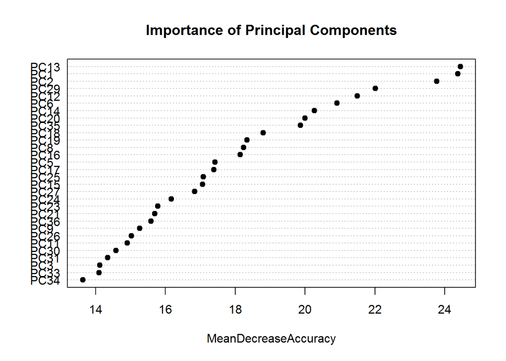

```r
varImpPlot(modelFit$finalModel, sort = TRUE, type = 1, pch = 19, col = 1, cex = 1, main = "Importance of Principal Components")
```

## Prediction for 20 Test Cases

With sufficiently high accuracy, the model is used to predict the 20 test cases.

```r
predict(modelFit,predictionPC)
```

```
##  [1] B A B A A E D B A A B C B A E E A B B B
## Levels: A B C D E
```